# Case 31: Summary of Data Analysis for H1 and H2

Employees Federal Credit Union

Author

Simran Kaur

Published

November 16, 2026

```r
library(tidyverse)
library(haven)
library(knitr)
options(knitr.kable.NA = "")

teal <- "#0D9488"
ink  <- "#052E2B"

theme_set(
  theme_minimal(base_size = 15, base_family = "sans") +
    theme(panel.grid.minor = element_blank(),
          plot.title.position = "plot",
          axis.text  = element_text(color = ink, face = "bold"),
          axis.title = element_text(color = ink, face = "bold"),
          legend.text = element_text(color = ink, face = "bold"))
)

efcu <- read_sav("Case 31 Data_efcu_4.sav")
d <- zap_labels(efcu) |>
  mutate(awareness = factor(q13_r, levels = 1:3,
                            labels = c("Unaware", "Aware, not used", "Aware and used")))

fmt_p <- function(p) ifelse(p < .001, "< .001", sprintf("%.3f", p))
```

## 1 About this report

This report tests the first two hypotheses for Case 31 using the cleaned data (**n = 128 members**).

- **H1:** Members’ **awareness of regular share accounts** (Q13r) will influence their opinion on **how well the CU’s financial services meet members’ needs** (Q33).
- **H2:** Members will **not differ** in their opinion of **the CU’s loan rates** (Q8r) and their agreement that **CU loan rates are lower than competitors’** (Q30).

The tests follow the data analysis table: a **one-way ANOVA** for H1 and a **paired-samples t-test** for H2. Each section shows the **descriptive statistics first**, then the test, then the **insight**. Statistics stay in parentheses and point to numbered tables and figures.

## 2 H1: Awareness of regular share accounts → services meet needs

### 2.1 H1: Descriptive statistics

```r
h1_desc <- d |>
  group_by(Awareness = awareness) |>
  summarise(n = n(),
            `% agree (4–5)` = 100 * mean(q33 >= 4),
            `% disagree (1–2)` = 100 * mean(q33 <= 2),
            Mean = mean(q33), SD = sd(q33), Median = median(q33))
h1_desc |> kable(digits = 2)
```

Table 1: Agreement that the CU’s services meet members’ needs (Q33), by awareness of regular share accounts (Q13r)

| Awareness | n | % agree (4–5) | % disagree (1–2) | Mean | SD | Median |
| --- | --- | --- | --- | --- | --- | --- |
| Unaware | 83 | 62.65 | 4.82 | 3.63 | 0.66 | 4 |
| Aware, not used | 32 | 62.50 | 0.00 | 3.72 | 0.63 | 4 |
| Aware and used | 13 | 30.77 | 23.08 | 3.08 | 0.76 | 3 |

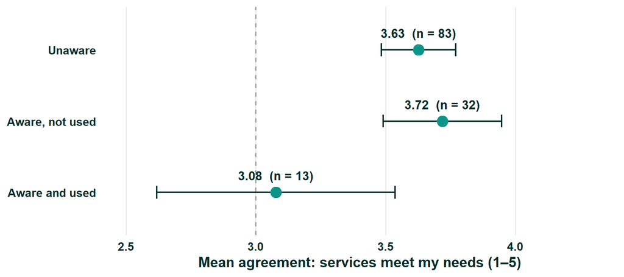

Figure 1: Mean agreement that services meet members’ needs, with 95% confidence intervals, by awareness of regular share accounts

```r
d |>
  group_by(awareness) |>
  summarise(n = n(), mean = mean(q33), se = sd(q33) / sqrt(n),
            lo = mean - qt(.975, n - 1) * se, hi = mean + qt(.975, n - 1) * se) |>
  ggplot(aes(mean, fct_rev(awareness))) +
  geom_vline(xintercept = 3, linetype = "dashed", color = "#9a9a9a") +
  geom_errorbarh(aes(xmin = lo, xmax = hi), height = 0.18, color = ink, linewidth = 0.8) +
  geom_point(size = 5, color = teal) +
  geom_text(aes(label = sprintf("%.2f  (n = %d)", mean, n)), vjust = -1.3,
            color = ink, fontface = "bold", size = 4.6) +
  scale_x_continuous(limits = c(2.5, 4.3), breaks = seq(2.5, 4.5, 0.5)) +
  labs(x = "Mean agreement: services meet my needs (1–5)", y = NULL) +
  theme(panel.grid.major.y = element_blank())
```

### 2.2 H1: Assumption check (equal variances)

```r
h1_bart <- bartlett.test(q33 ~ awareness, data = d)
h1_bart
```

```
    Bartlett test of homogeneity of variances

data:  q33 by awareness
Bartlett's K-squared = 0.60535, df = 2, p-value = 0.7388
```

The three groups have **similar spread** (Bartlett’s K²(2) = 0.61, *p* = 0.739), so the regular ANOVA is appropriate.

### 2.3 H1: One-way ANOVA

```r
h1_aov <- aov(q33 ~ awareness, data = d)
h1_tab <- summary(h1_aov)[[1]]
eta2   <- h1_tab[["Sum Sq"]][1] / sum(h1_tab[["Sum Sq"]])
tibble(Source = c("Awareness (Q13r)", "Residuals"),
       df = h1_tab$Df, `Sum Sq` = h1_tab$`Sum Sq`, `Mean Sq` = h1_tab$`Mean Sq`,
       F = h1_tab$`F value`, p = c(fmt_p(h1_tab$`Pr(>F)`[1]), "")) |>
  kable(digits = 2)
```

Table 2: One-way ANOVA: Q33 by awareness of regular share accounts

| Source | df | Sum Sq | Mean Sq | F | p |
| --- | --- | --- | --- | --- | --- |
| Awareness (Q13r) | 2 | 4.06 | 2.03 | 4.63 | 0.011 |
| Residuals | 125 | 54.81 | 0.44 |  |  |

```r
h1_welch <- oneway.test(q33 ~ awareness, data = d)
h1_kw    <- kruskal.test(q33 ~ awareness, data = d)
```

### 2.4 H1: Post-hoc test (Tukey HSD)

```r
TukeyHSD(h1_aov)$awareness |>
  as.data.frame() |>
  rownames_to_column("Comparison") |>
  transmute(Comparison, `Mean difference` = diff, `95% CI lower` = lwr,
            `95% CI upper` = upr, `Adjusted p` = fmt_p(`p adj`)) |>
  kable(digits = 2)
```

Table 3: Tukey HSD pairwise comparisons of mean Q33

| Comparison | Mean difference | 95% CI lower | 95% CI upper | Adjusted p |
| --- | --- | --- | --- | --- |
| Aware, not used-Unaware | 0.09 | -0.23 | 0.42 | 0.782 |
| Aware and used-Unaware | -0.55 | -1.02 | -0.08 | 0.017 |
| Aware and used-Aware, not used | -0.64 | -1.16 | -0.13 | 0.011 |

### 2.5 H1: Insight

**H1 is SUPPORTED, but in a surprising direction: the members who actually USE regular share accounts are the LEAST satisfied that EFCU meets their needs.**

- **Unaware and aware-but-not-used members look the same.** About **63% agree** that services meet their needs, with means of **3.63 and 3.72** (Table 1).
- **Members who have used regular share accounts stand apart.** Only **31% agree** and their mean drops to **3.08**, barely above neutral (Figure 1).
- **The differences are real, not chance** (*F*(2, 125) = 4.63, *p* = 0.011, η² = 0.07; Table 2). The **“used” group is lower than both other groups** (Tukey *p* = .017 and .011), while the other two don’t differ (*p* = .782; Table 3).
- **The result holds up** with the Welch ANOVA (*p* = 0.039) and the non-parametric Kruskal-Wallis test (*p* = 0.029), which matters because the “used” group is **small (n = 13)**.
- **So what:** the people with the **most hands-on experience** of EFCU’s core account are the **least convinced** it meets their needs. Experience seems to expose gaps that non-users never see. EFCU should **talk to its active account users** to find out what’s missing, whether that’s rates, features or convenience. Because the group is small, this is a **strong signal to investigate**, not a final verdict.

## 3 H2: Opinion of CU loan rates vs. “CU rates are lower than competitors”

### 3.1 H2: Descriptive statistics

```r
h2 <- d |> select(Q8_r, q30, q8) |> drop_na()
```

```r
tibble(
  Item = c("Q8r: CU loan rates (1 = very low, 5 = very high)",
           "Q30: CU loan rates lower than others (1 = strongly disagree, 5 = strongly agree)"),
  n = nrow(h2),
  `% at midpoint (3)` = c(100 * mean(h2$Q8_r == 3), 100 * mean(h2$q30 == 3)),
  `% 4–5` = c(100 * mean(h2$Q8_r >= 4), 100 * mean(h2$q30 >= 4)),
  `% 1–2` = c(100 * mean(h2$Q8_r <= 2), 100 * mean(h2$q30 <= 2)),
  Mean = c(mean(h2$Q8_r), mean(h2$q30)),
  SD = c(sd(h2$Q8_r), sd(h2$q30))
) |> kable(digits = 2)
```

Table 4: Loan rate opinions among members who answered both questions

| Item | n | % at midpoint (3) | % 4–5 | % 1–2 | Mean | SD |
| --- | --- | --- | --- | --- | --- | --- |
| Q8r: CU loan rates (1 = very low, 5 = very high) | 107 | 55.14 | 28.04 | 16.82 | 3.14 | 0.76 |
| Q30: CU loan rates lower than others (1 = strongly disagree, 5 = strongly agree) | 107 | 41.12 | 31.78 | 27.10 | 3.06 | 0.92 |

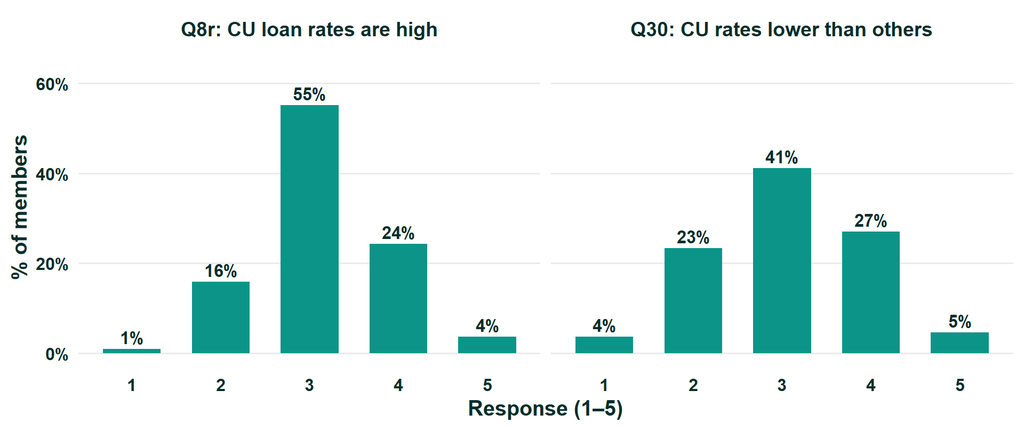

Figure 2: Distribution of answers to Q8r and Q30 (same members, n = 107)

```r
h2 |>
  select(`Q8r: CU loan rates are high` = Q8_r, `Q30: CU rates lower than others` = q30) |>
  pivot_longer(everything(), names_to = "item", values_to = "value") |>
  count(item, value) |>
  group_by(item) |>
  mutate(pct = 100 * n / sum(n)) |>
  ggplot(aes(factor(value), pct)) +
  geom_col(fill = teal, width = 0.65) +
  geom_text(aes(label = sprintf("%.0f%%", pct)), vjust = -0.4, color = ink,
            fontface = "bold", size = 4.4) +
  facet_wrap(~ factor(item, levels = c("Q8r: CU loan rates are high", "Q30: CU rates lower than others"))) +
  scale_y_continuous(limits = c(0, 65), labels = \(x) paste0(x, "%")) +
  labs(x = "Response (1–5)", y = "% of members") +
  theme(panel.grid.major.x = element_blank(),
        strip.text = element_text(color = ink, face = "bold", size = 14))
```

### 3.2 H2: Paired-samples t-test

```r
h2_t <- t.test(h2$Q8_r, h2$q30, paired = TRUE)
h2_t
```

```
    Paired t-test

data:  h2$Q8_r and h2$q30
t = 0.60088, df = 106, p-value = 0.5492
alternative hypothesis: true mean difference is not equal to 0
95 percent confidence interval:
 -0.1934139  0.3616382
sample estimates:
mean difference
     0.08411215
```

```r
tibble(Comparison = "Q8r − Q30", n = nrow(h2),
       `Mean difference` = unname(h2_t$estimate),
       `95% CI lower` = h2_t$conf.int[1], `95% CI upper` = h2_t$conf.int[2],
       t = unname(h2_t$statistic), df = unname(h2_t$parameter),
       p = fmt_p(h2_t$p.value)) |>
  kable(digits = 2)
```

Table 5: Paired-samples t-test: Q8r vs. Q30

| Comparison | n | Mean difference | 95% CI lower | 95% CI upper | t | df | p |
| --- | --- | --- | --- | --- | --- | --- | --- |
| Q8r − Q30 | 107 | 0.08 | -0.19 | 0.36 | 0.6 | 106 | 0.549 |

### 3.3 H2: Direction check (correlation and aligned comparison)

The two items **run in opposite directions**. A high Q8r means a member thinks EFCU’s rates are **high** (bad for the member), while a high Q30 means they agree EFCU’s rates are **lower** than competitors’ (good for the member). The correlation confirms it:

```r
h2_r       <- cor.test(h2$Q8_r, h2$q30)
h2_aligned <- t.test(h2$q8, h2$q30, paired = TRUE)
h2_r
```

```
    Pearson's product-moment correlation

data:  h2$Q8_r and h2$q30
t = -5.6835, df = 105, p-value = 1.193e-07
alternative hypothesis: true correlation is not equal to 0
95 percent confidence interval:
 -0.6179862 -0.3251183
sample estimates:
       cor
-0.4850371
```

```r
h2_aligned
```

```
    Paired t-test

data:  h2$q8 and h2$q30
t = -2.3534, df = 106, p-value = 0.02045
alternative hypothesis: true mean difference is not equal to 0
95 percent confidence interval:
 -0.36159829 -0.03092508
sample estimates:
mean difference
     -0.1962617
```

### 3.4 H2: Insight

**H2 is SUPPORTED as stated: members see EFCU’s loan rates as “average,” and they’re no more convinced the rates beat competitors’.**

- **Both answers cluster in the middle.** **55% call EFCU’s loan rates “average”** on Q8r, and **41% are uncertain** whether they beat other lenders on Q30 (Table 4, Figure 2).
- **The two means are practically identical**: **3.14 vs. 3.06**, with no significant difference (*t*(106) = 0.60, *p* = 0.549; Table 5). So the hypothesis of no difference holds.
- **A caution on reading this:** the two items point in **opposite directions**, and members answer them consistently. Those who think rates are high tend to disagree that rates beat competitors (*r* = -0.49, *p* < .001). When Q8 is put on the same direction as Q30 (original Q8, where 5 = very low), members are **slightly more positive about rates compared with competitors** than about rates in absolute terms, though the gap is **small** (2.86 vs. 3.06; *t*(106) = -2.35, *p* = 0.020).
- **So what:** **price is not a selling point for EFCU loans**. Members see the rates as neither cheap nor expensive, and they aren’t sure EFCU beats the competition. That matches R2, which pointed to **loan rates as the most likely reason members borrow elsewhere**. **Sharper, clearly communicated loan pricing** is the lever.

## 4 Summary

[output not shown]

## 5 Appendix

## 6 Appendix

- **GitHub Repository:** [Case 31 H1–H2](https://github.com/Simrank-DM/IBM6500-F26/tree/main/IC-Case%2031/IC-Case%2031%20-%20A%20Summary%20of%20Data%20Analysis%20for%20H1-H2)
- **GitHub Pages:** [Case 31 H1–H2 Report](https://simrank-dm.github.io/IBM6500-F26/IC-Case%2031/IC-Case%2031%20-%20A%20Summary%20of%20Data%20Analysis%20for%20H1-H2/IC-Case31-Summary-H1-H2-Simran-Kaur.html)